# R Notebook

# Setup

```r
#source(here::here("RScripts", "InitialProcessing_3.R"))
```

```r
library(vegan)
library(cowplot)
library(flextable)
library(ftExtra)
```

```r
source(here::here("RLibraries", "ChesapeakePersonalLibrary.R"))
```

This file is dedicated to conventional, non div-net/breakaway stats, since breakaway seems to choke on this data.

Reshape back into an ASV matrix, but this time correcting for total abundance

```r
nonSpikes %>% head
```

| ASV | reads | ID | Kingdom | Phylum | Class | Order | Family | Genus | nASV | TagLevel | Tag | Tag_ASV | Station | Size_Class | Depth | Bin_Size | DNAperLiter | MassperLiter | ParticlesPerLiter | Flag | SpikeReads | conversionMultiplier | RA | copiesPerL |
| --- | --- | --- | --- | --- | --- | --- | --- | --- | --- | --- | --- | --- | --- | --- | --- | --- | --- | --- | --- | --- | --- | --- | --- | --- |
| ASV_2 | 155 | 3-1-B-0-2 | Bacteria | Cyanobacteria | Oxyphotobacteria | Synechococcales | Cyanobiaceae | Cyanobium_PCC-6307 | 2 | Genus | Cyanobium_PCC-6307 | Cyanobium_PCC-6307;2 | 3.1 | 0.2 | Bottom | 1.0 | 3037.50000 | NA | NA | FALSE | 22523 | 13486.2141 | 0.002609735 | 2090363.18 |
| ASV_2 | 1893 | 3-1-B-1-2 | Bacteria | Cyanobacteria | Oxyphotobacteria | Synechococcales | Cyanobiaceae | Cyanobium_PCC-6307 | 2 | Genus | Cyanobium_PCC-6307 | Cyanobium_PCC-6307;2 | 3.1 | 1.2 | Bottom | 3.8 | 4791.66667 | 18.5000000 | 1.205105e+10 | FALSE | 20193 | 23729.3452 | 0.025714519 | 44919650.37 |
| ASV_2 | 383 | 3-1-B-180 | Bacteria | Cyanobacteria | Oxyphotobacteria | Synechococcales | Cyanobiaceae | Cyanobium_PCC-6307 | 2 | Genus | Cyanobium_PCC-6307 | Cyanobium_PCC-6307;2 | 3.1 | 180.0 | Bottom | 320.0 | 79.61905 | 0.5001143 | 5.462835e+04 | FALSE | 19006 | 418.9153 | 0.012380398 | 160444.57 |
| ASV_2 | 167 | 3-1-B-20 | Bacteria | Cyanobacteria | Oxyphotobacteria | Synechococcales | Cyanobiaceae | Cyanobium_PCC-6307 | 2 | Genus | Cyanobium_PCC-6307 | Cyanobium_PCC-6307;2 | 3.1 | 20.0 | Bottom | 33.0 | 168.10268 | 12.3509250 | 8.675916e+06 | FALSE | 7228 | 2325.7150 | 0.006699294 | 388394.40 |
| ASV_2 | 302 | 3-1-B-5 | Bacteria | Cyanobacteria | Oxyphotobacteria | Synechococcales | Cyanobiaceae | Cyanobium_PCC-6307 | 2 | Genus | Cyanobium_PCC-6307 | Cyanobium_PCC-6307;2 | 3.1 | 5.0 | Bottom | 15.0 | 2191.62162 | 36.1851892 | 4.045780e+08 | FALSE | 27174 | 8065.1418 | 0.007547547 | 2435672.81 |
| ASV_2 | 44 | 3-1-B-500 | Bacteria | Cyanobacteria | Oxyphotobacteria | Synechococcales | Cyanobiaceae | Cyanobium_PCC-6307 | 2 | Genus | Cyanobium_PCC-6307 | Cyanobium_PCC-6307;2 | 3.1 | 500.0 | Bottom | 500.0 | 11.00794 | 0.2822857 | 2.812675e+03 | FALSE | 3432 | 320.7441 | 0.010251631 | 14112.74 |

```r
raDf <- nonSpikes %>% pivot_wider(id_cols = ID, names_from = ASV, values_from = RA, values_fill = 0)
raMat <- raDf %>% column_to_rownames("ID")
```

```r
raMat1 <- raMat %>% as.matrix()
```

```r
countMat <-  nonSpikes %>%
  pivot_wider(id_cols = ID, names_from = ASV, values_from = reads, values_fill = 0) %>%
  column_to_rownames("ID") %>% as.matrix()
```

```r
seqDep <- countMat %>% apply(1, sum)
min(seqDep)
```

```
[1] 852
```

```r
sampleRichness <- rarefy(countMat, min(seqDep))
```

rarefy everything to the minimum depth (852)

```r
countRare <- rrarefy(countMat, min(seqDep))
```

Gamma diversity

```r
specpool(countRare)
```

|  | Species | chao | chao.se | jack1 | jack1.se | jack2 | boot | boot.se | n |
| --- | --- | --- | --- | --- | --- | --- | --- | --- | --- |
| All | 7120 | 33266.76 | 1355.686 | 12339.47 | 783.2794 | 16981.42 | 9140.435 | 329.7574 | 75 |

Doesn’t finish

```r
#specpool(countMat)
```

# Calculate diversity indeces

All richness estimates

```r
richnessRare <- estimateR(countRare)
```

Shannon diversity

```r
shan <- diversity(countRare)
shan
```

```
 3-1-B-0-2  3-1-B-1-2  3-1-B-180   3-1-B-20    3-1-B-5  3-1-B-500   3-1-B-53  3-1-S-0-2  3-1-S-1-2  3-1-S-180   3-1-S-20    3-1-S-5  3-2-B-0-2
  4.294853   5.202708   4.688801   5.987489   5.146093   3.872424   5.539731   4.562370   4.874896   4.773756   5.299213   4.872360   4.481482
 3-2-B-1-2  3-2-B-180   3-2-B-20    3-2-B-5  3-2-B-500   3-2-B-53  3-2-S-0-2  3-2-S-1-2  3-2-S-180   3-2-S-20    3-2-S-5  3-2-S-500   3-2-S-53
  4.778115   4.682978   5.079299   5.488779   5.117207   4.955346   3.723789   5.027694   4.731843   4.895389   5.165019   4.821781   4.328619
 3-3-B-0-2  3-3-B-1-2  3-3-B-180   3-3-B-20    3-3-B-5  3-3-B-500   3-3-B-53  3-3-S-180   3-3-S-20  3-3-S-500   3-3-S-53  4-3-B-0-2  4-3-B-1-2
  4.399909   4.872249   3.447575   5.770920   5.270933   5.356413   5.429808   5.105799   4.916764   4.901895   4.347936   4.263399   4.904017
 4-3-B-180   4-3-B-20    4-3-B-5  4-3-B-500   4-3-B-53  4-3-O-1-2  4-3-O-180    4-3-O-5  4-3-O-500   4-3-O-53  4-3-S-0-2  4-3-S-180   4-3-S-20
  4.432685   4.367720   4.640879   4.429712   4.323231   5.080974   4.695662   5.131390   4.000001   4.437514   2.805419   4.494350   4.531490
 4-3-S-500   4-3-S-53  5-1-S-1-2  5-1-S-180   5-1-S-20    5-1-S-5  5-1-S-500   5-1-S-53  5-5-B-0-2  5-5-B-180    5-5-B-5  5-5-B-500   5-5-B-53
  4.771991   4.486400   4.416481   4.497670   4.166469   4.027828   3.949323   4.185891   4.568207   5.193567   5.477397   5.100467   4.963880
 5-5-S-180    5-5-S-5  5-5-S-500   5-5-S-53 C_5P1B_0P2 C_5P1B_180 C_5P1B_1P2  C_5P1B_20 C_5P1B_500  C_5P1B_53
  4.358307   5.069812   4.851308   4.278430   4.264407   4.786866   4.824637   5.418153   4.783451   5.167434
```

Evenness

```r
pielouJ <- shan/richnessRare["S.chao1",]
pielouJ
```

```
  3-1-B-0-2   3-1-B-1-2   3-1-B-180    3-1-B-20     3-1-B-5   3-1-B-500    3-1-B-53   3-1-S-0-2   3-1-S-1-2   3-1-S-180    3-1-S-20     3-1-S-5
0.015224138 0.008223540 0.010630519 0.002757008 0.007045421 0.041864042 0.008722078 0.008214757 0.006841677 0.009421267 0.007090302 0.008240595
  3-2-B-0-2   3-2-B-1-2   3-2-B-180    3-2-B-20     3-2-B-5   3-2-B-500    3-2-B-53   3-2-S-0-2   3-2-S-1-2   3-2-S-180    3-2-S-20     3-2-S-5
0.012376677 0.007498162 0.012029669 0.006062233 0.006624489 0.008484082 0.011646162 0.020560800 0.007220845 0.009818592 0.007646390 0.006753866
  3-2-S-500    3-2-S-53   3-3-B-0-2   3-3-B-1-2   3-3-B-180    3-3-B-20     3-3-B-5   3-3-B-500    3-3-B-53   3-3-S-180    3-3-S-20   3-3-S-500
0.009844388 0.012756245 0.010796377 0.008922552 0.051456336 0.005716424 0.007595561 0.006422558 0.005798031 0.008411273 0.008014418 0.010243061
   3-3-S-53   4-3-B-0-2   4-3-B-1-2   4-3-B-180    4-3-B-20     4-3-B-5   4-3-B-500    4-3-B-53   4-3-O-1-2   4-3-O-180     4-3-O-5   4-3-O-500
0.010585184 0.011943340 0.008102837 0.009495419 0.010965406 0.010333379 0.009798537 0.010231922 0.009307491 0.010062786 0.005241027 0.015776267
   4-3-O-53   4-3-S-0-2   4-3-S-180    4-3-S-20   4-3-S-500    4-3-S-53   5-1-S-1-2   5-1-S-180    5-1-S-20     5-1-S-5   5-1-S-500    5-1-S-53
0.014164552 0.124685269 0.014422459 0.012954518 0.010129918 0.014212054 0.011481816 0.011233963 0.012007114 0.011135385 0.014544734 0.013949650
  5-5-B-0-2   5-5-B-180     5-5-B-5   5-5-B-500    5-5-B-53   5-5-S-180     5-5-S-5   5-5-S-500    5-5-S-53  C_5P1B_0P2  C_5P1B_180  C_5P1B_1P2
0.009053424 0.007849371 0.006226999 0.011273179 0.009436682 0.013279145 0.009793036 0.009755636 0.017853570 0.008176941 0.006116814 0.006200536
  C_5P1B_20  C_5P1B_500   C_5P1B_53
0.003443108 0.007123251 0.005736891
```

## Combine diversity data

```r
diversityData <- sampleData %>%
  left_join(richnessRare %>% t() %>% as.data.frame() %>% rownames_to_column("ID"), by = "ID") %>%
  left_join(shan %>% enframe(name = "ID", value = "shannonH"), by = "ID") %>%
  left_join(pielouJ %>% enframe(name = "ID", value = "pielouJ"), by = "ID") %>%
  arrange(Size_Class)
```

# Generate plots of diversity estimates

Parameters for all plots

```r
plotSpecs <- list(
  facet_wrap(~Depth, ncol = 1) ,
  theme_bw(base_size = 16) ,
  geom_point(size = 4) ,
  geom_path(aes(color = as.factor(Station))) ,
  scale_x_log10(breaks = my_sizes, labels = as.character(my_sizes)) ,
  #scale_y_log10nice() ,
  scale_shape_manual(values = rep(21:25, 2)) ,
  scale_fill_viridis_d(option = "plasma") ,
  scale_color_viridis_d(option = "plasma") ,
  labs(x = expression(paste("Particle Size (", mu, "m)"))) ,
  theme(legend.position = "none",
        plot.margin = unit(c(0, 0, 0, 0), "cm"),
        axis.title.x = element_blank(),
        axis.text.x = element_text(angle = 90, vjust = .5),
        axis.title.y = element_text(margin = unit(c(3, 3, 3, 3), "mm"), vjust = 0))
)
```

Observed species counts, on rarefied data

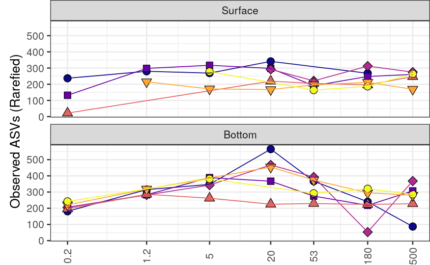

```r
plotObs <- diversityData %>%
filter(Depth %in% c("Surface", "Bottom")) %>%
  ggplot(aes(x = Size_Class, y = S.obs, shape = as.factor(Station), fill = as.factor(Station))) +
  plotSpecs +ylab("Observed ASVs (Rarefied)")#+ scale_y_log10()
plotObs
```

Estemated Chao1 Richness

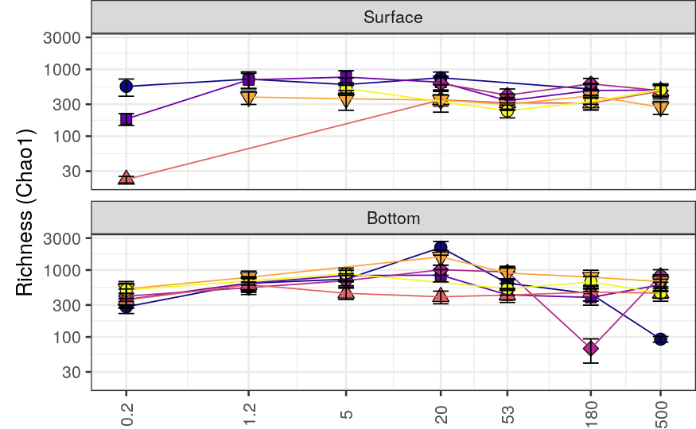

```r
plotChao1 <- diversityData %>%
filter(Depth %in% c("Surface", "Bottom")) %>%
  ggplot(aes(x = Size_Class, y = S.chao1, shape = as.factor(Station), fill = as.factor(Station))) +
  plotSpecs +
  geom_errorbar(aes(ymin = S.chao1 -2 * se.chao1, ymax = S.chao1 + 2* se.chao1), width = -.1) +
  scale_y_log10() +
  ylab("Richness (Chao1)")
plotChao1
```

Shannon diversity

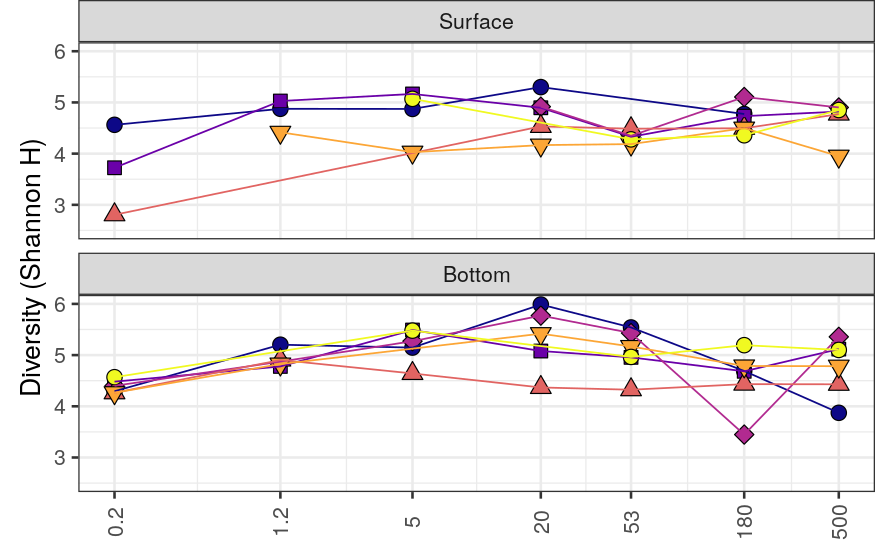

```r
plotShan <- diversityData %>%
filter(Depth %in% c("Surface", "Bottom")) %>%
  ggplot(aes(x = Size_Class, y = shannonH, shape = as.factor(Station), fill = as.factor(Station))) +
  plotSpecs +
  ylab("Diversity (Shannon H)") +
  lims(y = c(2.5, 6))
plotShan
```

Evenness

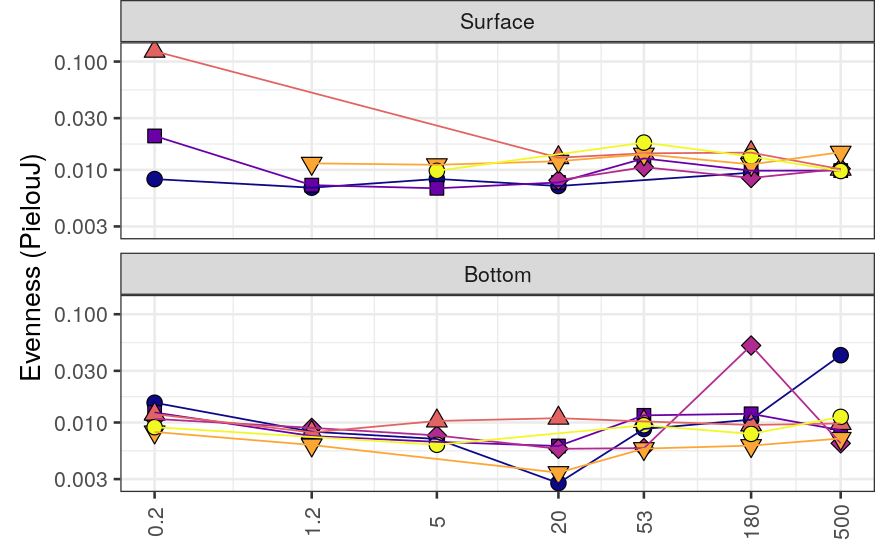

```r
plotPielou <- diversityData %>%

filter(Depth %in% c("Surface", "Bottom")) %>%
  ggplot(aes(x = Size_Class, y = pielouJ, shape = as.factor(Station), fill = as.factor(Station))) +
  plotSpecs +scale_y_log10() +ylab("Evenness (PielouJ)")
plotPielou
```

All plots together

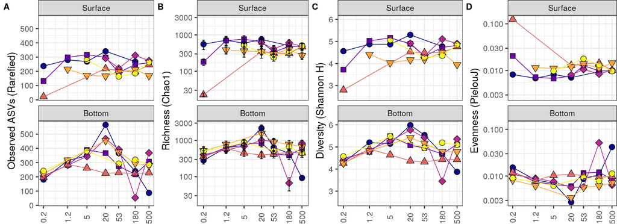

```r
plotAlpha <- plot_grid(plotObs, plotChao1, plotShan, plotPielou, nrow = 1, labels = LETTERS)
plotAlpha
```

```r
ggsave(here::here("Figures", "ConventionalAlpha.png"), plotAlpha, width = 11, height = 4)
```

## Do we see trends with lat and size?

## Observed Species

Rarefied

```r
obsMod <- lm(S.obs ~ log(Size_Class) + I(log(Size_Class)^2) + I(log(Size_Class)^2) + lat + I(lat^2) + depth, data = diversityData)
summary(obsMod)
```

```
Call:
lm(formula = S.obs ~ log(Size_Class) + I(log(Size_Class)^2) +
    I(log(Size_Class)^2) + lat + I(lat^2) + depth, data = diversityData)

Residuals:
     Min       1Q   Median       3Q      Max
-223.164  -42.272    1.146   44.604  223.133

Coefficients:
                       Estimate Std. Error t value Pr(>|t|)
(Intercept)          292180.132 136530.797   2.140 0.035890 *
log(Size_Class)          33.236      8.272   4.018 0.000148 ***
I(log(Size_Class)^2)     -6.533      1.539  -4.245 6.69e-05 ***
lat                  -15218.431   7114.443  -2.139 0.035969 *
I(lat^2)                198.226     92.616   2.140 0.035869 *
depth                     4.891      3.276   1.493 0.140072
---
Signif. codes:  0 ‘***’ 0.001 ‘**’ 0.01 ‘*’ 0.05 ‘.’ 0.1 ‘ ’ 1

Residual standard error: 77.77 on 69 degrees of freedom
Multiple R-squared:  0.2734,    Adjusted R-squared:  0.2207
F-statistic: 5.192 on 5 and 69 DF,  p-value: 0.0004212
```

## Richness

```r
chao1Mod <- lm(S.chao1 ~ log(Size_Class) + I(log(Size_Class)^2) + I(log(Size_Class)^2) + lat + I(lat^2) + depth, data = diversityData)
summary(chao1Mod)
```

```
Call:
lm(formula = S.chao1 ~ log(Size_Class) + I(log(Size_Class)^2) +
    I(log(Size_Class)^2) + lat + I(lat^2) + depth, data = diversityData)

Residuals:
    Min      1Q  Median      3Q     Max
-536.93 -169.05  -25.03  126.40 1384.40

Coefficients:
                       Estimate Std. Error t value Pr(>|t|)
(Intercept)           1.081e+06  4.964e+05   2.177 0.032918 *
log(Size_Class)       9.230e+01  3.008e+01   3.069 0.003070 **
I(log(Size_Class)^2) -1.961e+01  5.596e+00  -3.504 0.000809 ***
lat                  -5.634e+04  2.587e+04  -2.178 0.032844 *
I(lat^2)              7.341e+02  3.368e+02   2.180 0.032680 *
depth                 2.282e+01  1.191e+01   1.916 0.059564 .
---
Signif. codes:  0 ‘***’ 0.001 ‘**’ 0.01 ‘*’ 0.05 ‘.’ 0.1 ‘ ’ 1

Residual standard error: 282.8 on 69 degrees of freedom
Multiple R-squared:  0.2137,    Adjusted R-squared:  0.1567
F-statistic: 3.751 on 5 and 69 DF,  p-value: 0.004613
```

```r
chao1ModSimple <- lm(S.chao1 ~ log(Size_Class) + I(log(Size_Class)^2), data = diversityData)
summary(chao1ModSimple)
```

```
Call:
lm(formula = S.chao1 ~ log(Size_Class) + I(log(Size_Class)^2),
    data = diversityData)

Residuals:
    Min      1Q  Median      3Q     Max
-456.34 -197.59  -19.07  113.36 1491.02

Coefficients:
                     Estimate Std. Error t value Pr(>|t|)
(Intercept)           582.719     51.522  11.310  < 2e-16 ***
log(Size_Class)        92.898     30.598   3.036 0.003335 **
I(log(Size_Class)^2)  -20.091      5.692  -3.530 0.000729 ***
---
Signif. codes:  0 ‘***’ 0.001 ‘**’ 0.01 ‘*’ 0.05 ‘.’ 0.1 ‘ ’ 1

Residual standard error: 288 on 72 degrees of freedom
Multiple R-squared:  0.1488,    Adjusted R-squared:  0.1251
F-statistic: 6.292 on 2 and 72 DF,  p-value: 0.003031
```

## Shannon Diversity

```r
shanMod <- lm(shannonH ~ log(Size_Class) + I(log(Size_Class)^2) + lat + I(lat^2) + depth, data = diversityData)
```

```r
summary(shanMod)
```

```
Call:
lm(formula = shannonH ~ log(Size_Class) + I(log(Size_Class)^2) +
    lat + I(lat^2) + depth, data = diversityData)

Residuals:
     Min       1Q   Median       3Q      Max
-1.34317 -0.21688  0.02408  0.30998  0.79110

Coefficients:
                       Estimate Std. Error t value Pr(>|t|)
(Intercept)           1.655e+03  7.952e+02   2.081   0.0412 *
log(Size_Class)       2.066e-01  4.818e-02   4.288 5.73e-05 ***
I(log(Size_Class)^2) -3.745e-02  8.964e-03  -4.179 8.45e-05 ***
lat                  -8.594e+01  4.144e+01  -2.074   0.0418 *
I(lat^2)              1.119e+00  5.394e-01   2.074   0.0418 *
depth                 1.729e-02  1.908e-02   0.906   0.3680
---
Signif. codes:  0 ‘***’ 0.001 ‘**’ 0.01 ‘*’ 0.05 ‘.’ 0.1 ‘ ’ 1

Residual standard error: 0.4529 on 69 degrees of freedom
Multiple R-squared:   0.31, Adjusted R-squared:   0.26
F-statistic:   6.2 on 5 and 69 DF,  p-value: 8.394e-05
```

## Evenness

```r
pielouMod <- lm(pielouJ ~ log(Size_Class) + I(log(Size_Class)^2) + lat + I(lat^2) + depth, data = diversityData)
summary(pielouMod)
```

```
Call:
lm(formula = pielouJ ~ log(Size_Class) + I(log(Size_Class)^2) +
    lat + I(lat^2) + depth, data = diversityData)

Residuals:
      Min        1Q    Median        3Q       Max
-0.013741 -0.005478 -0.001809  0.001726  0.099074

Coefficients:
                       Estimate Std. Error t value Pr(>|t|)
(Intercept)          -3.108e+01  2.536e+01  -1.225   0.2246
log(Size_Class)      -4.050e-03  1.537e-03  -2.636   0.0104 *
I(log(Size_Class)^2)  7.003e-04  2.859e-04   2.450   0.0168 *
lat                   1.619e+00  1.322e+00   1.225   0.2247
I(lat^2)             -2.107e-02  1.720e-02  -1.225   0.2249
depth                -5.281e-04  6.086e-04  -0.868   0.3885
---
Signif. codes:  0 ‘***’ 0.001 ‘**’ 0.01 ‘*’ 0.05 ‘.’ 0.1 ‘ ’ 1

Residual standard error: 0.01445 on 69 degrees of freedom
Multiple R-squared:  0.1148,    Adjusted R-squared:  0.05063
F-statistic: 1.789 on 5 and 69 DF,  p-value: 0.1265
```

# Prediction plots

## Observed Species

```r
predict(obsMod, se.fit = TRUE)
```

```
$fit
       1        2        3        4        5        6        7        8        9       10       11       12       13       14       15       16
230.5213 230.5213 197.2456 197.2456 209.3447 156.0342 156.0342 186.5342 200.1284 306.7779 306.7779 273.5022 273.5022 285.6013 232.2908 232.2908
      17       18       19       20       21       22       23       24       25       26       27       28       29       30       31       32
262.7908 262.7908 337.5027 337.5027 304.2270 304.2270 316.3261 263.0156 263.0156 293.5156 307.1098 307.1098 341.8668 341.8668 308.5910 308.5910
      33       34       35       36       37       38       39       40       41       42       43       44       45       46       47       48
320.6902 320.6902 267.3797 267.3797 297.8796 297.8796 329.9026 296.6268 296.6268 308.7260 308.7260 255.4155 255.4155 255.4155 285.9155 285.9155
      49       50       51       52       53       54       55       56       57       58       59       60       61       62       63       64
299.5097 299.5097 297.3406 297.3406 264.0649 264.0649 276.1641 276.1641 222.8536 222.8536 222.8536 253.3535 253.3535 266.9478 266.9478 255.1515
      65       66       67       68       69       70       71       72       73       74       75
221.8758 221.8758 233.9749 233.9749 180.6644 180.6644 180.6644 211.1644 211.1644 224.7586 224.7586

$se.fit
 [1] 27.20562 27.20562 26.46388 26.46388 26.32265 28.00423 28.00423 29.57667 34.31137 19.08437 19.08437 18.46305 18.46305 17.33896 20.20122 20.20122
[17] 21.67583 21.67583 19.40870 19.40870 18.94317 18.94317 17.37458 20.24829 20.24829 21.37550 28.40339 28.40339 19.40651 19.40651 18.90981 18.90981
[33] 17.09810 17.09810 19.76850 19.76850 20.74072 20.74072 18.71115 18.06698 18.06698 16.12676 16.12676 18.59133 18.59133 18.59133 19.59030 19.59030
[49] 26.76797 26.76797 19.46739 19.46739 18.57328 18.57328 16.81452 16.81452 18.57480 18.57480 18.57480 19.65562 19.65562 26.32483 26.32483 24.65637
[65] 23.69560 23.69560 22.52469 22.52469 23.32696 23.32696 23.32696 24.33443 24.33443 29.46176 29.46176

$df
[1] 69

$residual.scale
[1] 77.76625
```

```r
diversityData$pred_obs = predict(obsMod, se.fit = TRUE)$fit
diversityData$se_obs = predict(obsMod, se.fit = TRUE)$se.fit
```

```r
plotSpecs2 <- list(
  facet_wrap(~Depth, ncol = 1) ,
  theme_bw(base_size = 16) ,
  #geom_point(size = 4) ,
  geom_path(aes(color = as.factor(Station))) ,
  scale_x_log10(breaks = my_sizes, labels = as.character(my_sizes)) ,
  #scale_y_log10nice() ,
  scale_shape_manual(values = rep(21:25, 2)) ,
  scale_fill_viridis_d(option = "plasma") ,
  scale_color_viridis_d(option = "plasma") ,
  labs(x = expression(paste("Particle Size (", mu, "m)"))) ,
  theme(legend.position = "none",
        plot.margin = unit(c(0, 0, 0, 0), "cm"),
        axis.title.x = element_blank(),
        axis.text.x = element_text(angle = 90, vjust = .5),
        axis.title.y = element_text(margin = unit(c(3, 3, 3, 3), "mm"), vjust = 0))
)
```

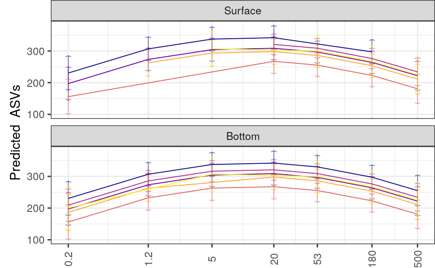

```r
plotObs_pred <-  diversityData %>%
filter(Depth %in% c("Surface", "Bottom")) %>%
  ggplot(aes(x = Size_Class, y = pred_obs, shape = as.factor(Station), fill = as.factor(Station))) +
  geom_segment(aes(y = pred_obs - 2 * se_obs, yend = pred_obs + 2 * se_obs, xend = Size_Class, color = as.factor(Station)), arrow = arrow(angle = 70, length = unit(0.05, "in"), ends = "both"), alpha = 0.5)  +
  plotSpecs2 + ylab("Predicted  ASVs")
plotObs_pred
```

## Richness

```r
predict(chao1Mod, se.fit = TRUE)
```

```
$fit
       1        2        3        4        5        6        7        8        9       10       11       12       13       14       15       16
487.4450 487.4450 357.0602 357.0602 454.0353 260.5841 260.5841 401.9932 359.7427 702.9697 702.9697 572.5849 572.5849 669.5600 476.1088 476.1088
      17       18       19       20       21       22       23       24       25       26       27       28       29       30       31       32
617.5179 617.5179 784.5568 784.5568 654.1719 654.1719 751.1471 557.6959 557.6959 699.1050 656.8545 656.8545 787.3326 787.3326 656.9477 656.9477
      33       34       35       36       37       38       39       40       41       42       43       44       45       46       47       48
753.9229 753.9229 560.4717 560.4717 701.8808 701.8808 744.1688 613.7839 613.7839 710.7590 710.7590 517.3078 517.3078 517.3078 658.7170 658.7170
      49       50       51       52       53       54       55       56       57       58       59       60       61       62       63       64
616.4664 616.4664 637.3385 637.3385 506.9536 506.9536 603.9288 603.9288 410.4776 410.4776 410.4776 551.8867 551.8867 509.6362 509.6362 503.1112
      65       66       67       68       69       70       71       72       73       74       75
372.7263 372.7263 469.7015 469.7015 276.2503 276.2503 276.2503 417.6594 417.6594 375.4089 375.4089

$se.fit
 [1]  98.92016  98.92016  96.22318  96.22318  95.70968 101.82392 101.82392 107.54136 124.75679  69.39116  69.39116  67.13201  67.13201  63.04479
[15]  73.45201  73.45201  78.81375  78.81375  70.57042  70.57042  68.87772  68.87772  63.17432  73.62318  73.62318  77.72174 103.27526 103.27526
[29]  70.56244  70.56244  68.75642  68.75642  62.16903  62.16903  71.87864  71.87864  75.41365  75.41365  68.03412  65.69187  65.69187  58.63723
[43]  58.63723  67.59842  67.59842  67.59842  71.23071  71.23071  97.32886  97.32886  70.78379  70.78379  67.53281  67.53281  61.13793  61.13793
[57]  67.53833  67.53833  67.53833  71.46822  71.46822  95.71759  95.71759  89.65104  86.15765  86.15765  81.90020  81.90020  84.81727  84.81727
[71]  84.81727  88.48044  88.48044 107.12352 107.12352

$df
[1] 69

$residual.scale
[1] 282.7596
```

```r
diversityData$pred_chao1 = predict(chao1Mod, se.fit = TRUE)$fit
diversityData$se_chao1 = predict(chao1Mod, se.fit = TRUE)$se.fit
```

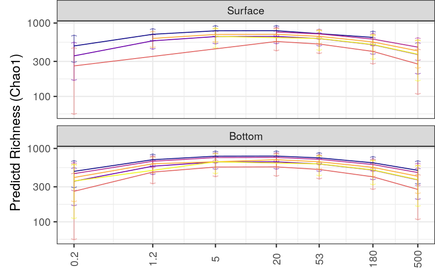

```r
plotChao1_pred <-  diversityData %>%

filter(Depth %in% c("Surface", "Bottom")) %>%
  ggplot(aes(x = Size_Class, y = pred_chao1, shape = as.factor(Station), fill = as.factor(Station))) +
  geom_segment(aes(y = pred_chao1 - 2 * se_chao1, yend = pred_chao1 + 2 * se_chao1, xend = Size_Class, color = as.factor(Station)), arrow = arrow(angle = 70, length = unit(0.05, "in"), ends = "both"), alpha = 0.5)  +
  plotSpecs2 + ylab("Predictd Richness (Chao1)") + scale_y_log10()
plotChao1_pred
```

## Shannon Diversity

```r
predict(shanMod, se.fit = TRUE)
```

```
$fit
       1        2        3        4        5        6        7        8        9       10       11       12       13       14       15       16
4.514293 4.514293 4.342878 4.342878 4.298337 3.992422 3.992422 4.104186 4.388751 4.980251 4.980251 4.808837 4.808837 4.764296 4.458380 4.458380
      17       18       19       20       21       22       23       24       25       26       27       28       29       30       31       32
4.570145 4.570145 5.179328 5.179328 5.007914 5.007914 4.963373 4.657457 4.657457 4.769222 5.053787 5.053787 5.226632 5.226632 5.055217 5.055217
      33       34       35       36       37       38       39       40       41       42       43       44       45       46       47       48
5.010677 5.010677 4.704761 4.704761 4.816526 4.816526 5.173712 5.002297 5.002297 4.957756 4.957756 4.651840 4.651840 4.651840 4.763605 4.763605
      49       50       51       52       53       54       55       56       57       58       59       60       61       62       63       64
5.048170 5.048170 5.006699 5.006699 4.835285 4.835285 4.790744 4.790744 4.484828 4.484828 4.484828 4.596593 4.596593 4.881158 4.881158 4.781266
      65       66       67       68       69       70       71       72       73       74       75
4.609852 4.609852 4.565311 4.565311 4.259395 4.259395 4.259395 4.371160 4.371160 4.655724 4.655724

$se.fit
 [1] 0.15844811 0.15844811 0.15412815 0.15412815 0.15330562 0.16309928 0.16309928 0.17225735 0.19983264 0.11114920 0.11114920 0.10753056 0.10753056
[14] 0.10098373 0.11765379 0.11765379 0.12624210 0.12624210 0.11303812 0.11303812 0.11032680 0.11032680 0.10119122 0.11792797 0.11792797 0.12449294
[27] 0.16542401 0.16542401 0.11302534 0.11302534 0.11013251 0.11013251 0.09958097 0.09958097 0.11513360 0.11513360 0.12079591 0.12079591 0.10897554
[40] 0.10522378 0.10522378 0.09392380 0.09392380 0.10827765 0.10827765 0.10827765 0.11409577 0.11409577 0.15589919 0.15589919 0.11337990 0.11337990
[53] 0.10817254 0.10817254 0.09792937 0.09792937 0.10818139 0.10818139 0.10818139 0.11447620 0.11447620 0.15331830 0.15331830 0.14360103 0.13800541
[66] 0.13800541 0.13118591 0.13118591 0.13585841 0.13585841 0.13585841 0.14172599 0.14172599 0.17158807 0.17158807

$df
[1] 69

$residual.scale
[1] 0.452918
```

```r
diversityData$pred_shanH = predict(shanMod, se.fit = TRUE)$fit
diversityData$se_shanH = predict(shanMod, se.fit = TRUE)$se.fit
```

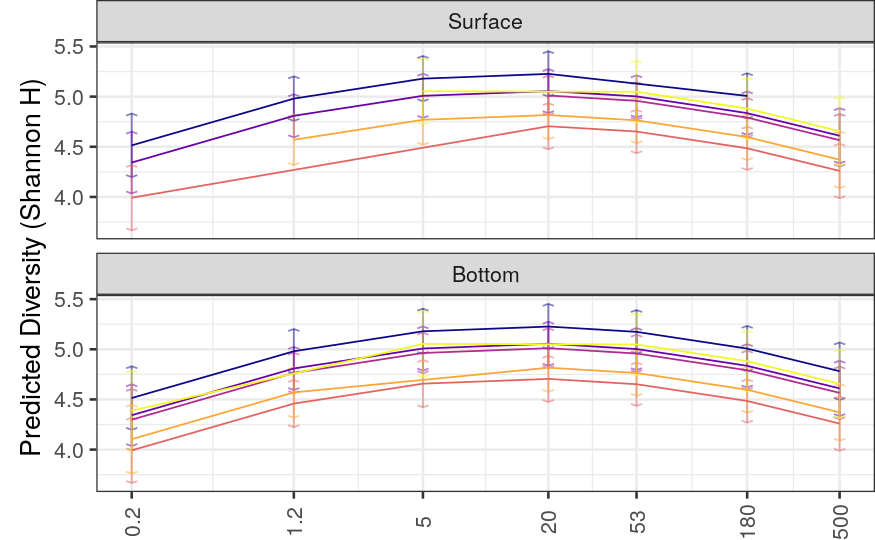

```r
plotShannonH_pred <- diversityData %>%

 filter(Depth %in% c("Surface", "Bottom")) %>%
  ggplot(aes(x = Size_Class, y = pred_shanH, shape = as.factor(Station), fill = as.factor(Station))) +
  geom_segment(aes(y = pred_shanH - 2 * se_shanH, yend = pred_shanH + 2 * se_shanH, xend = Size_Class, color = as.factor(Station)), arrow = arrow(angle = 70, length = unit(0.05, "in"), ends = "both"),  alpha = 0.5)  +
  plotSpecs2 + ylab("Predicted Diversity (Shannon H)") #+ scale_y_log10()
plotShannonH_pred
```

## Evenness

```r
predict(pielouMod, se.fit = TRUE)
```

```
$fit
          1           2           3           4           5           6           7           8           9          10          11          12
0.018960258 0.018960258 0.022363892 0.022363892 0.020700754 0.025611283 0.025611283 0.021918090 0.019573564 0.009912311 0.009912311 0.013315945
         13          14          15          16          17          18          19          20          21          22          23          24
0.013315945 0.011652807 0.016563336 0.016563336 0.012870143 0.012870143 0.005922792 0.005922792 0.009326426 0.009326426 0.007663288 0.012573817
         25          26          27          28          29          30          31          32          33          34          35          36
0.012573817 0.008880624 0.006536098 0.006536098 0.004778793 0.004778793 0.008182426 0.008182426 0.006519289 0.006519289 0.011429818 0.011429818
         37          38          39          40          41          42          43          44          45          46          47          48
0.007736625 0.007736625 0.005585858 0.008989492 0.008989492 0.007326354 0.007326354 0.012236883 0.012236883 0.012236883 0.008543690 0.008543690
         49          50          51          52          53          54          55          56          57          58          59          60
0.006199164 0.006199164 0.008479777 0.008479777 0.011883411 0.011883411 0.010220274 0.010220274 0.015130803 0.015130803 0.015130803 0.011437610
         61          62          63          64          65          66          67          68          69          70          71          72
0.011437610 0.009093084 0.009093084 0.012503690 0.015907323 0.015907323 0.014244186 0.014244186 0.019154715 0.019154715 0.019154715 0.015461522
         73          74          75
0.015461522 0.013116996 0.013116996

$se.fit
 [1] 0.005053830 0.005053830 0.004916041 0.004916041 0.004889806 0.005202183 0.005202183 0.005494287 0.006373823 0.003545193 0.003545193 0.003429774
[13] 0.003429774 0.003220957 0.003752662 0.003752662 0.004026593 0.004026593 0.003605442 0.003605442 0.003518962 0.003518962 0.003227575 0.003761408
[25] 0.003761408 0.003970803 0.005276332 0.005276332 0.003605034 0.003605034 0.003512765 0.003512765 0.003176215 0.003176215 0.003672279 0.003672279
[37] 0.003852883 0.003852883 0.003475862 0.003356197 0.003356197 0.002995775 0.002995775 0.003453603 0.003453603 0.003453603 0.003639176 0.003639176
[49] 0.004972530 0.004972530 0.003616343 0.003616343 0.003450250 0.003450250 0.003123536 0.003123536 0.003450533 0.003450533 0.003450533 0.003651311
[61] 0.003651311 0.004890211 0.004890211 0.004580270 0.004401794 0.004401794 0.004184280 0.004184280 0.004333313 0.004333313 0.004333313 0.004520465
[73] 0.004520465 0.005472940 0.005472940

$df
[1] 69

$residual.scale
[1] 0.01444618
```

```r
diversityData$pred_pielouJ = predict(pielouMod, se.fit = TRUE)$fit
diversityData$se_pielouJ = predict(pielouMod, se.fit = TRUE)$se.fit
```

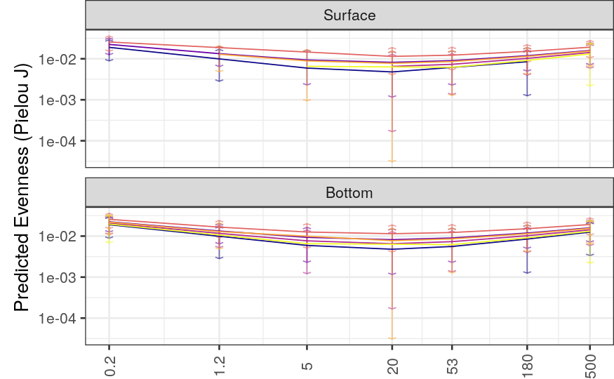

```r
plot_pielouJ_pred <- diversityData %>%

filter(Depth %in% c("Surface", "Bottom")) %>%
  ggplot(aes(x = Size_Class, y = pred_pielouJ, shape = as.factor(Station), fill = as.factor(Station))) +
  geom_segment(aes(y = pred_pielouJ - 2 * se_pielouJ, yend = pred_pielouJ + 2 * se_pielouJ, xend = Size_Class, color = as.factor(Station), alpha = 0.5), arrow = arrow(angle = 70, length = unit(0.05, "in"), ends = "both"))  +
  plotSpecs2 + ylab("Predicted Evenness (Pielou J)") + scale_y_log10()
plot_pielouJ_pred
```

## Combined prediction plot

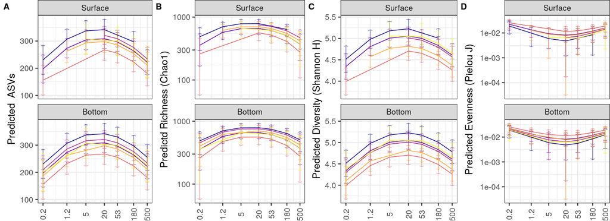

```r
plotPredictions <- plot_grid(plotObs_pred, plotChao1_pred, plotShannonH_pred, plot_pielouJ_pred, nrow = 1, labels = LETTERS)
plotPredictions
```

```r
ggsave(here::here("Figures", "ConventionalAlphaPredictions.png"), plotPredictions, width = 11, height = 4)
```

## Even combindeder

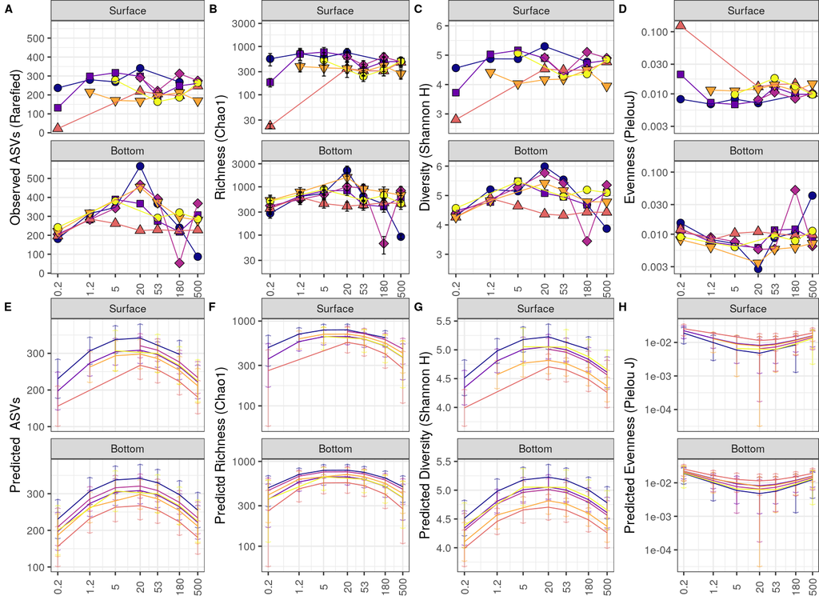

```r
plot_grid(plotObs, plotChao1, plotShan, plotPielou,
          plotObs_pred, plotChao1_pred, plotShannonH_pred, plot_pielouJ_pred,
          nrow = 2, labels = LETTERS)
```

# Combined summary table

```r
alphaSummary <- tibble(
  metric = c("Observed ASVs", "Richness (Chao1)", "Diversity (Shannon H)", "Evenness (Pielou J)"),
  model = list(obsMod, chao1Mod, shanMod, pielouMod)
)

alphaSummary <- alphaSummary %>%
  mutate(df = map(model, ~broom::tidy(summary(.))))

alphaSummary <- alphaSummary %>%
  select(-model) %>%
  unnest(df)

alphaSummary <- alphaSummary %>%
  rename(Metric = metric, Term = term, Estimate = estimate, `Standard Error` = std.error, `T Value` = statistic, p = p.value) %>%
  mutate(Term = str_replace(Term, "^I?\\((.*)\\)", "\\1"),
         Term = str_replace(Term, "\\^2", "\\^2\\^"),
         Term = str_replace(Term, "depth", "Depth"),
         Term = str_replace(Term, "lat", "Latitude"),
         Term = str_replace(Term, "_", " ")# BOOKMARK!!
         ) %>%
  mutate(Estimate = format(Estimate, digits = 2, scientific = TRUE) %>%
           reformat_sci()
         ) %>%
  mutate(`Standard Error` = format(`Standard Error`, digits = 2, scientific = TRUE) %>%
           reformat_sci()
  ) %>%
  mutate(`T Value` = format(`T Value`, digits = 2, scientific = FALSE)) %>%
  mutate(p = if_else(p < 0.001, "< 0.001", format(round(p, digits = 3)))) %>%
  rename(`Standard\nError` = `Standard Error`) %>%
  identity()

alphaSummary %>% flextable() %>% merge_v(j = 1) %>% theme_vanilla() %>% bold(i = ~ p< 0.05, j = "p") %>% colformat_md() %>% set_table_properties(layout = "autofit") %>%
  align(j = -c(1:2), align = "right")
```

| Metric | Term | Estimate | Standard Error | T Value | p |
| --- | --- | --- | --- | --- | --- |
| Observed ASVs | Intercept | 2.9 x 105 | 1.4 x 105 | 2.14 | 0.036 |
|  | log(Size Class) | 3.3 x 101 | 8.3 x 100 | 4.02 | < 0.001 |
|  | log(Size Class)2 | -6.5 x 100 | 1.5 x 100 | -4.25 | < 0.001 |
|  | Latitude | -1.5 x 104 | 7.1 x 103 | -2.14 | 0.036 |
|  | Latitude2 | 2.0 x 102 | 9.3 x 101 | 2.14 | 0.036 |
|  | Depth | 4.9 x 100 | 3.3 x 100 | 1.49 | 0.140 |
| Richness (Chao1) | Intercept | 1.1 x 106 | 5.0 x 105 | 2.18 | 0.033 |
|  | log(Size Class) | 9.2 x 101 | 3.0 x 101 | 3.07 | 0.003 |
|  | log(Size Class)2 | -2.0 x 101 | 5.6 x 100 | -3.50 | < 0.001 |
|  | Latitude | -5.6 x 104 | 2.6 x 104 | -2.18 | 0.033 |
|  | Latitude2 | 7.3 x 102 | 3.4 x 102 | 2.18 | 0.033 |
|  | Depth | 2.3 x 101 | 1.2 x 101 | 1.92 | 0.060 |
| Diversity (Shannon H) | Intercept | 1.7 x 103 | 8.0 x 102 | 2.08 | 0.041 |
|  | log(Size Class) | 2.1 x 10-1 | 4.8 x 10-2 | 4.29 | < 0.001 |
|  | log(Size Class)2 | -3.7 x 10-2 | 9.0 x 10-3 | -4.18 | < 0.001 |
|  | Latitude | -8.6 x 101 | 4.1 x 101 | -2.07 | 0.042 |
|  | Latitude2 | 1.1 x 100 | 5.4 x 10-1 | 2.07 | 0.042 |
|  | Depth | 1.7 x 10-2 | 1.9 x 10-2 | 0.91 | 0.368 |
| Evenness (Pielou J) | Intercept | -3.1 x 101 | 2.5 x 101 | -1.23 | 0.225 |
|  | log(Size Class) | -4.1 x 10-3 | 1.5 x 10-3 | -2.64 | 0.010 |
|  | log(Size Class)2 | 7.0 x 10-4 | 2.9 x 10-4 | 2.45 | 0.017 |
|  | Latitude | 1.6 x 100 | 1.3 x 100 | 1.23 | 0.225 |
|  | Latitude2 | -2.1 x 10-2 | 1.7 x 10-2 | -1.22 | 0.225 |
|  | Depth | -5.3 x 10-4 | 6.1 x 10-4 | -0.87 | 0.389 |

# Now considering breakaway values

```r
richSummary %>% rename_(.dots = setNames(names(.), paste0('break_', names(.))))
```

| break_estimate | break_error | break_lower | break_upper | break_sample_names | break_name | break_model |
| --- | --- | --- | --- | --- | --- | --- |
| 1149.49504 | 74.215916 | 840.37860 | 9.856215e+03 | 3-1-B-0-2 | breakaway | Negative Binomial |
| 3759.74532 | 600.496435 | 2190.46255 | 1.549200e+05 | 3-1-B-1-2 | breakaway | Kemp |
| 852.96618 | 95.814707 | 626.33788 | 1.070146e+04 | 3-1-B-180 | breakaway | Kemp |
| 8590.39015 | 367.922431 | 4335.69492 | 1.720644e+05 | 3-1-B-20 | breakaway | Kemp |
| 2272.34292 | 128.244212 | 1422.82197 | 2.732167e+04 | 3-1-B-5 | breakaway | Kemp |
| 100.14731 | 9.881637 | 87.75180 | 3.169175e+02 | 3-1-B-500 | breakaway | Negative Binomial |
| 2104.54130 | 197.020727 | 1259.66143 | 4.120062e+04 | 3-1-B-53 | breakaway | Kemp |
| 2274.51944 | 342.357498 | 1130.16308 | 7.971937e+04 | 3-1-S-0-2 | breakaway | Kemp |
| 3711.49178 | 372.223587 | 1937.21385 | 1.096785e+05 | 3-1-S-1-2 | breakaway | Kemp |
| 3936.99093 | 995.618813 | 2130.27993 | 2.515435e+05 | 3-1-S-180 | breakaway | Kemp |

[output cut: 65 more lines]

```r
diversityDataWB <- full_join(diversityData,
                             richSummary %>% rename_(.dots = setNames(names(.), paste0('break_', names(.)))),
                             by = c("ID" = "break_sample_names"), suffix = c("", "_break")) %>%
  mutate(pielouJ2 = shannonH/break_estimate) %>%
  identity()
```

```r
diversityDataWB
```

| ID | copiesPerL | Station | Size_Class | Depth | Bin_Size | DNAperLiter | MassperLiter | ParticlesPerLiter | Flag | lat | long | UTMX | UTMY | depth | do | Depth2 | S.obs | S.chao1 | se.chao1 | S.ACE | se.ACE | shannonH | pielouJ | pred_obs | se_obs | pred_chao1 | se_chao1 | pred_shanH | se_shanH | … |
| --- | --- | --- | --- | --- | --- | --- | --- | --- | --- | --- | --- | --- | --- | --- | --- | --- | --- | --- | --- | --- | --- | --- | --- | --- | --- | --- | --- | --- | --- | --- |
| 3-1-S-0-2 | 7.688621e+08 | 3.1 | 0.2 | Surface | 1.0 | 3.690476e+03 | NA | NA | FALSE | 39.24950 | -76.24050 | 392959 | 4345197 | 13.3 | 85 | Surface | 237 | 555.3871 | 79.868409 | 512.63324 | 13.351485 | 4.562370 | 0.008214757 | 230.5213 | 27.20562 | 487.4450 | 98.92016 | 4.514293 | 0.15844811 | … |
| 3-1-B-0-2 | 4.968996e+08 | 3.1 | 0.2 | Bottom | 1.0 | 3.037500e+03 | NA | NA | FALSE | 39.24950 | -76.24050 | 392959 | 4345197 | 13.3 | 85 | NotSurface | 181 | 282.1081 | 29.075369 | 332.68748 | 11.744231 | 4.294853 | 0.015224138 | 230.5213 | 27.20562 | 487.4450 | 98.92016 | 4.514293 | 0.15844811 | … |
| 3-2-S-0-2 | 1.642566e+09 | 3.2 | 0.2 | Surface | 1.0 | 3.625000e+03 | NA | NA | FALSE | 39.16369 | -76.30631 | 387143 | 4335754 | 12.2 | 54 | Surface | 132 | 181.1111 | 18.007668 | 195.45034 | 8.227321 | 3.723789 | 0.020560800 | 197.2456 | 26.46388 | 357.0602 | 96.22318 | 4.342878 | 0.15412815 | … |
| 3-2-B-0-2 | 1.221752e+09 | 3.2 | 0.2 | Bottom | 1.0 | 4.647059e+03 | NA | NA | FALSE | 39.16369 | -76.30631 | 387143 | 4335754 | 12.2 | 54 | NotSurface | 206 | 362.0909 | 42.858748 | 359.67202 | 11.590694 | 4.481482 | 0.012376677 | 197.2456 | 26.46388 | 357.0602 | 96.22318 | 4.342878 | 0.15412815 | … |
| 3-3-B-0-2 | 9.999237e+08 | 3.3 | 0.2 | Bottom | 1.0 | 1.839286e+03 | NA | NA | FALSE | 38.99596 | -76.35967 | 382254 | 4317207 | 24.1 | 10 | NotSurface | 205 | 407.5357 | 56.240727 | 376.82574 | 11.630851 | 4.399909 | 0.010796377 | 209.3447 | 26.32265 | 454.0353 | 95.70968 | 4.298337 | 0.15330562 | … |
| 4-3-S-0-2 | 1.625097e+07 | 4.3 | 0.2 | Surface | 1.0 | 6.875000e+03 | NA | NA | FALSE | 38.55505 | -76.42794 | 375578 | 4268368 | 27.1 | 8 | Surface | 22 | 22.5000 | 1.289380 | 25.46182 | 1.880563 | 2.805419 | 0.124685269 | 156.0342 | 28.00423 | 260.5841 | 101.82392 | 3.992422 | 0.16309928 | … |
| 4-3-B-0-2 | 6.977776e+08 | 4.3 | 0.2 | Bottom | 1.0 | 1.589286e+03 | NA | NA | FALSE | 38.55505 | -76.42794 | 375578 | 4268368 | 27.1 | 8 | NotSurface | 196 | 356.9688 | 44.401123 | 367.95325 | 11.453431 | 4.263399 | 0.011943340 | 156.0342 | 28.00423 | 260.5841 | 101.82392 | 3.992422 | 0.16309928 | … |
| C_5P1B_0P2 | 1.124669e+09 | 5.1 | 0.2 | Bottom | 1.0 | 2.962500e+03 | NA | NA | FALSE | 38.31870 | -76.29215 | 387043 | 4241966 | 34.3 | 11 | NotSurface | 221 | 521.5161 | 75.998052 | 547.30710 | 14.645033 | 4.264407 | 0.008176941 | 186.5342 | 29.57667 | 401.9932 | 107.54136 | 4.104186 | 0.17225735 | … |
| 5-5-B-0-2 | 2.292876e+10 | 5.5 | 0.2 | Bottom | 1.0 | 4.354839e+03 | NA | NA | FALSE | 37.69180 | -76.18967 | 395112 | 4172286 | 17.7 | 56 | NotSurface | 242 | 504.5833 | 64.324618 | 494.54379 | 13.650565 | 4.568207 | 0.009053424 | 200.1284 | 34.31137 | 359.7427 | 124.75679 | 4.388751 | 0.19983264 | … |
| 3-1-S-1-2 | 1.467958e+09 | 3.1 | 1.2 | Surface | 3.8 | 3.478723e+03 | 6.34000000 | 2.665037e+09 | FALSE | 39.24950 | -76.24050 | 392959 | 4345197 | 13.3 | 85 | Surface | 280 | 712.5294 | 100.742183 | 641.41409 | 15.755020 | 4.874896 | 0.006841677 | 306.7779 | 19.08437 | 702.9697 | 69.39116 | 4.980251 | 0.11114920 | … |

[output cut: 65 more lines]

```r
pielouMod2 <- lm(pielouJ2 ~ log(Size_Class) + I(log(Size_Class)^2) + lat + I(lat^2) + depth, data = diversityDataWB)
summary(pielouMod2)
```

```
Call:
lm(formula = pielouJ2 ~ log(Size_Class) + I(log(Size_Class)^2) +
    lat + I(lat^2) + depth, data = diversityDataWB)

Residuals:
      Min        1Q    Median        3Q       Max
-0.013957 -0.005132 -0.002519  0.000878  0.105970

Coefficients:
                       Estimate Std. Error t value Pr(>|t|)
(Intercept)          -1.960e+01  2.754e+01  -0.712   0.4791
log(Size_Class)      -3.283e-03  1.669e-03  -1.967   0.0532 .
I(log(Size_Class)^2)  5.737e-04  3.105e-04   1.848   0.0689 .
lat                   1.019e+00  1.435e+00   0.710   0.4800
I(lat^2)             -1.324e-02  1.869e-02  -0.709   0.4809
depth                -2.392e-04  6.610e-04  -0.362   0.7186
---
Signif. codes:  0 ‘***’ 0.001 ‘**’ 0.01 ‘*’ 0.05 ‘.’ 0.1 ‘ ’ 1

Residual standard error: 0.01569 on 69 degrees of freedom
Multiple R-squared:  0.06688,   Adjusted R-squared:  -0.0007367
F-statistic: 0.9891 on 5 and 69 DF,  p-value: 0.4309
```

Ok. So the narrative makes sense. Alpha diveristy is driven by variability in richness rather than evenness. Why would we see an effect in chao1 but not breakaway? Because chao1 is more driven by abundant stuff that makes the rarification threshold. My first hunch is that chao1 responds to evenness, but actually that shouldn’t have any effect since there is no evenness variability? Or maybe just that breakaway is more variable (because it detects fine level differences in rare species) and that doesn’t map as nicely with overall patterns.

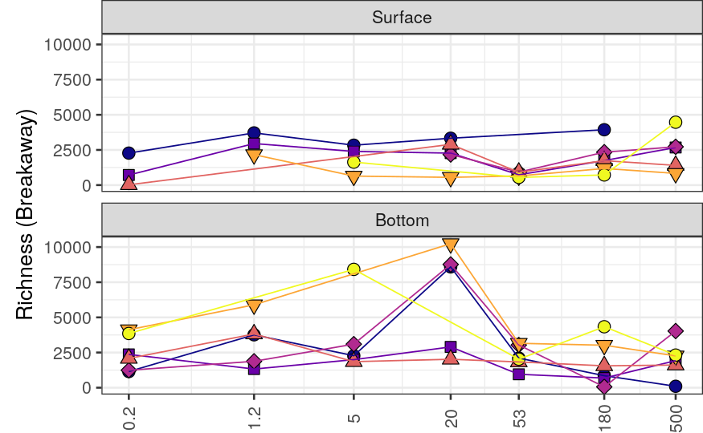

```r
plotBreak <- diversityDataWB %>%

filter(Depth %in% c("Surface", "Bottom")) %>%
  ggplot(aes(x = Size_Class, y = break_estimate, shape = as.factor(Station), fill = as.factor(Station))) +
  plotSpecs +
  #scale_y_log10()+
  ylab("Richness (Breakaway)")
plotBreak
```

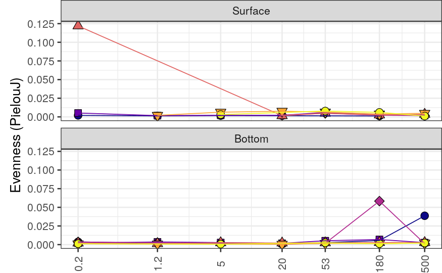

```r
plotPielou2 <- diversityDataWB %>%

filter(Depth %in% c("Surface", "Bottom")) %>%
  ggplot(aes(x = Size_Class, y = pielouJ2, shape = as.factor(Station), fill = as.factor(Station))) +
  plotSpecs +
  #scale_y_log10()+
  ylab("Evenness (PielouJ)")
plotPielou2
```

## Redo predictions for good measure

```r
predict(pielouMod2, se.fit = TRUE)
```

```
$fit
            1             2             3             4             5             6             7             8             9            10
 0.0116805212  0.0116805212  0.0135774668  0.0135774668  0.0133616938  0.0160050153  0.0160050153  0.0139647209  0.0099244121  0.0043311262
           11            12            13            14            15            16            17            18            19            20
 0.0043311262  0.0062280718  0.0062280718  0.0060122988  0.0086556204  0.0086556204  0.0066153259  0.0066153259  0.0011129042  0.0011129042
           21            22            23            24            25            26            27            28            29            30
 0.0030098498  0.0030098498  0.0027940768  0.0054373983  0.0054373983  0.0033971039 -0.0006432049 -0.0006432049  0.0002243569  0.0002243569
           31            32            33            34            35            36            37            38            39            40
 0.0021213025  0.0021213025  0.0019055295  0.0019055295  0.0045488511  0.0045488511  0.0025085566  0.0025085566  0.0009197152  0.0028166608
           41            42            43            44            45            46            47            48            49            50
 0.0028166608  0.0026008878  0.0026008878  0.0052442094  0.0052442094  0.0052442094  0.0032039149  0.0032039149 -0.0008363939 -0.0008363939
           51            52            53            54            55            56            57            58            59            60
 0.0033333717  0.0033333717  0.0052303173  0.0052303173  0.0050145443  0.0050145443  0.0076578659  0.0076578659  0.0076578659  0.0056175714
           61            62            63            64            65            66            67            68            69            70
 0.0056175714  0.0015772626  0.0015772626  0.0066656883  0.0085626339  0.0085626339  0.0083468609  0.0083468609  0.0109901825  0.0109901825
           71            72            73            74            75
 0.0109901825  0.0089498880  0.0089498880  0.0049095792  0.0049095792

$se.fit
 [1] 0.005488619 0.005488619 0.005338976 0.005338976 0.005310484 0.005649735 0.005649735 0.005966969 0.006922173 0.003850192 0.003850192 0.003724843
[13] 0.003724843 0.003498062 0.004075510 0.004075510 0.004373008 0.004373008 0.003915624 0.003915624 0.003821704 0.003821704 0.003505249 0.004085007
[25] 0.004085007 0.004312417 0.005730263 0.005730263 0.003915181 0.003915181 0.003814974 0.003814974 0.003449470 0.003449470 0.003988211 0.003988211
[37] 0.004184352 0.004184352 0.003774896 0.003644936 0.003644936 0.003253507 0.003253507 0.003750722 0.003750722 0.003750722 0.003952261 0.003952261
[49] 0.005400325 0.005400325 0.003927463 0.003927463 0.003747081 0.003747081 0.003392259 0.003392259 0.003747387 0.003747387 0.003747387 0.003965439
[61] 0.003965439 0.005310923 0.005310923 0.004974318 0.004780487 0.004780487 0.004544260 0.004544260 0.004706115 0.004706115 0.004706115 0.004909367
[73] 0.004909367 0.005943785 0.005943785

$df
[1] 69

$residual.scale
[1] 0.01568901
```

```r
diversityDataWB$pred_pielouJ2 = predict(pielouMod2, se.fit = TRUE)$fit
diversityDataWB$se_pielouJ2 = predict(pielouMod2, se.fit = TRUE)$se.fit
```

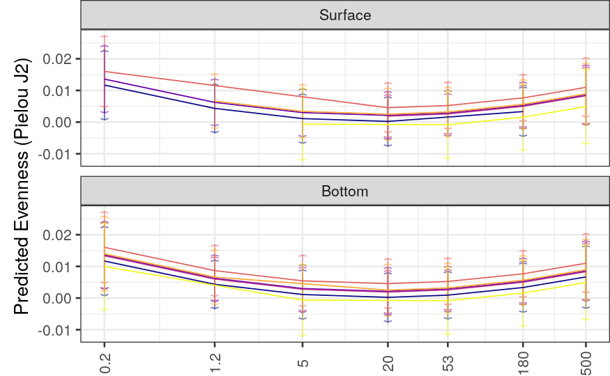

```r
plot_pielouJ_pred <- diversityDataWB %>%

filter(Depth %in% c("Surface", "Bottom")) %>%
  ggplot(aes(x = Size_Class, y = pred_pielouJ2, shape = as.factor(Station), fill = as.factor(Station))) +
  geom_segment(aes(y = pred_pielouJ2 - 2 * se_pielouJ2, yend = pred_pielouJ2 + 2 * se_pielouJ2, xend = Size_Class, color = as.factor(Station), alpha = 0.5), arrow = arrow(angle = 70, length = unit(0.05, "in"), ends = "both"))  +
  plotSpecs2 + ylab("Predicted Evenness (Pielou J2)") #+ scale_y_log10()
plot_pielouJ_pred
```

## Breakaway richness subplots

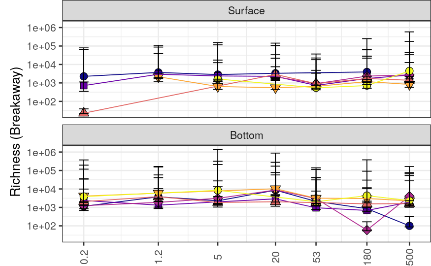

```r
plotBreakaway <- diversityDataWB %>%
filter(Depth %in% c("Surface", "Bottom")) %>%
  ggplot(aes(x = Size_Class, y = break_estimate, shape = as.factor(Station), fill = as.factor(Station))) +
  plotSpecs +
  geom_errorbar(aes(ymin = break_lower, ymax = break_upper), width = -.1) +
  scale_y_log10() +
  ylab("Richness (Breakaway)")
plotBreakaway
```

```r
predict(breakLm, se.fit = TRUE)
```

```
$fit
        1         2         3         4         5         6         7         8         9        10        11        12        13        14        15
2539.4000 3169.5807 2370.1342 3185.3106 3326.2543 1743.9336 2913.3026 2539.4000 3169.5807 2370.1342 3185.3106 3326.2543 1757.9616 2388.1423 1588.6959
       16        17        18        19        20        21        22        23        24        25        26        27        28        29        30
2403.8722 2544.8160  962.4953 2131.8642 1757.9616 2388.1423 1588.6959 2403.8722 2544.8160  962.4953 2131.8642 2558.4030 3188.5836 2389.1372 3204.3135
       31        32        33        34        35        36        37        38        39        40        41        42        43        44        45
3345.2573 1762.9366 2932.3056 2389.1372 3204.3135 1762.9366 2932.3056 1681.8219 2312.0026 1512.5561 2327.7325 2468.6763  886.3555 2055.7245 2312.0026
       46        47        48        49        50        51        52        53        54        55        56        57        58        59        60
1512.5561 2468.6763  886.3555 2055.7245 1681.8219 1512.5561 2327.7325  886.3555 2055.7245 3458.1654 2658.7189 3473.8953 3614.8390 2032.5183 3201.8873
       61        62        63        64        65        66        67        68        69        70        71        72        73        74        75
3081.0357 2911.7700 3867.8901 2285.5694 3454.9383 2911.7700 3867.8901 2285.5694 3454.9383 2827.9847 2658.7189 3458.1654 3473.8953 2032.5183 3201.8873

$se.fit
 [1] 665.5132 466.8485 476.2178 474.7286 474.7823 603.1525 457.7186 665.5132 466.8485 476.2178 474.7286 474.7823 647.3685 451.6495 454.3459 462.5782
[17] 463.3942 579.6498 441.9605 647.3685 451.6495 454.3459 462.5782 463.3942 579.6498 441.9605 643.9137 424.1515 411.3226 418.2596 425.0230 551.0066
[33] 394.4984 411.3226 418.2596 551.0066 394.4984 685.0490 494.1690 454.3831 483.5837 495.3206 570.6320 454.7874 494.1690 454.3831 495.3206 570.6320
[49] 454.7874 685.0490 454.3831 483.5837 570.6320 454.7874 530.2416 480.8225 507.3665 522.8948 595.2770 479.2246 839.3363 643.9670 694.8133 720.7036
[65] 654.8072 643.9670 694.8133 720.7036 654.8072 723.5147 480.8225 530.2416 507.3665 595.2770 479.2246

$df
[1] 69

$residual.scale
[1] 1902.344
```

```r
diversityDataWB$pred_break = predict(breakLm, se.fit = TRUE)$fit
diversityDataWB$se_break = predict(breakLm, se.fit = TRUE)$se.fit
```

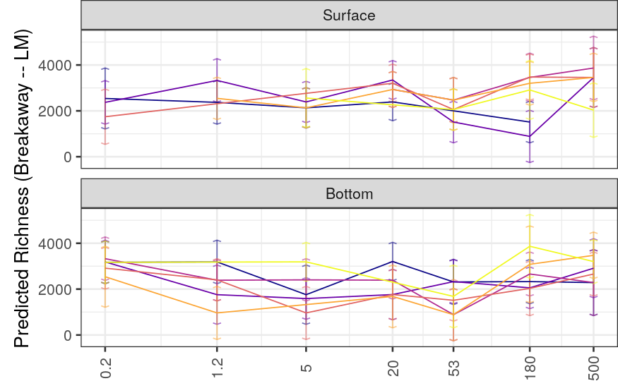

```r
plot_break_pred <- diversityDataWB %>%

filter(Depth %in% c("Surface", "Bottom")) %>%
  ggplot(aes(x = Size_Class, y = pred_break, shape = as.factor(Station), fill = as.factor(Station))) +
  geom_segment(aes(y = pred_break - 2 * se_break, yend = pred_break + 2 * se_break, xend = Size_Class, color = as.factor(Station), alpha = 0.5), arrow = arrow(angle = 70, length = unit(0.05, "in"), ends = "both"))  +
  plotSpecs2 + ylab("Predicted Richness (Breakaway -- LM)") #+ scale_y_log10()
plot_break_pred
```

## Rebuilding combined products

[figure not shown]

```r
plotAlphaWB <- plot_grid(plotBreakaway, plotShan, plotPielou2, nrow = 1, labels = LETTERS)
plotAlphaWB
```

```r
ggsave(here::here("Figures", "BreakawayAlpha.png"), plotAlpha, width = 11, height = 4)
```

Summary table I want both breakaway metrics here

```r
bettaTable <- myBet$table %>%
  as.data.frame() %>%
  rename(estimate = Estimates,
         `std.error` = `Standard Errors`,
         `p.value`=`p-values`
         ) %>%
  mutate(`statistic` = NA) %>%
  rownames_to_column(var = "term") %>%
  select(term, estimate, std.error, statistic, p.value) %>%
  as_tibble()
bettaTable
```

| term | estimate | std.error | statistic | p.value |
| --- | --- | --- | --- | --- |
| (Intercept) | 7124599.39073 | 238.1841898 | NA | 0.000 |
| log(Size_Class) | 115.12754 | 60.7376176 | NA | 0.058 |
| I(log(Size_Class)^2) | -50.49272 | 11.6218766 | NA | 0.000 |
| lat | -370742.10322 | 6.1494273 | NA | 0.000 |
| I(lat^2) | 4821.69098 | 0.1587166 | NA | 0.000 |
| depth | 150.02477 | 10.3193582 | NA | 0.000 |

```r
alphaSummary2 <- tibble(
  metric = c("Richness (Breakaway -- LM)", "Diversity (Shannon H)", "Evenness (Pielou J)"),
  model = list(breakLm, shanMod, pielouMod2)
)

alphaSummary2 <- alphaSummary2 %>%
  mutate(df = map(model, ~broom::tidy(summary(.))))

## Add in willis variables

breakawaySummary <- tibble(
  metric = "Richness (Breakaway -- Betta)",
  model = NULL,
  df = list(bettaTable)
)

alphaSummary2 = bind_rows(breakawaySummary, alphaSummary2)

alphaSummary2 <- alphaSummary2 %>%
  select(-model) %>%
  unnest(df)

alphaSummary2 <- alphaSummary2 %>%
  rename(Metric = metric, Term = term, Estimate = estimate, `Standard Error` = std.error, `T Value` = statistic, p = p.value) %>%
  mutate(Term = str_replace(Term, "^I?\\((.*)\\)", "\\1"),
         Term = str_replace(Term, "\\^2", "\\^2\\^"),
         Term = str_replace(Term, "depth", "Depth"),
         Term = str_replace(Term, "lat", "Latitude"),
         Term = str_replace(Term, "_", " ")# BOOKMARK!!
         ) %>%
  mutate(Estimate = format(Estimate, digits = 2, scientific = TRUE) %>%
           reformat_sci()
         ) %>%
  mutate(`Standard Error` = format(`Standard Error`, digits = 2, scientific = TRUE) %>%
           reformat_sci()
  ) %>%
  mutate(`T Value` = format(`T Value`, digits = 2, scientific = FALSE)) %>%
  mutate(p = if_else(p < 0.001, "< 0.001", format(round(p, digits = 3)))) %>%
  rename(`Standard\nError` = `Standard Error`) %>%
  identity()



alphaSummary2
```

| Metric | Term | Estimate | Standard Error | T Value | p |
| --- | --- | --- | --- | --- | --- |
| Richness (Breakaway -- Betta) | Intercept | 7.1 x 10^6^ | 2.4 x 10^2^ | NA | < 0.001 |
| Richness (Breakaway -- Betta) | log(Size Class) | 1.2 x 10^2^ | 6.1 x 10^1^ | NA | 0.058 |
| Richness (Breakaway -- Betta) | log(Size Class)^2^ | -5.0 x 10^1^ | 1.2 x 10^1^ | NA | < 0.001 |
| Richness (Breakaway -- Betta) | Latitude | -3.7 x 10^5^ | 6.1 x 10^0^ | NA | < 0.001 |
| Richness (Breakaway -- Betta) | Latitude^2^ | 4.8 x 10^3^ | 1.6 x 10^-1^ | NA | < 0.001 |
| Richness (Breakaway -- Betta) | Depth | 1.5 x 10^2^ | 1.0 x 10^1^ | NA | < 0.001 |
| Richness (Breakaway -- LM) | Intercept | 7.1 x 10^6^ | 3.3 x 10^6^ | 2.13 | 0.036 |
| Richness (Breakaway -- LM) | log(Size Class) | 2.4 x 10^2^ | 2.0 x 10^2^ | 1.21 | 0.231 |
| Richness (Breakaway -- LM) | log(Size Class)^2^ | -7.5 x 10^1^ | 3.8 x 10^1^ | -2.00 | 0.050 |
| Richness (Breakaway -- LM) | Latitude | -3.7 x 10^5^ | 1.7 x 10^5^ | -2.13 | 0.037 |

[output cut: 14 more lines]

```r
alphaSummary2 %>% flextable() %>% merge_v(j = 1) %>% theme_vanilla() %>% bold(i = ~ p< 0.05, j = "p") %>% colformat_md() %>% set_table_properties(layout = "autofit") %>%
  align(j = -c(1:2), align = "right")
```

[output not shown]

myBet$table

## And finally predictions from richness, diversity evenness again.